# 36-315 Homework 05, Fall 2021

SOLUTIONS

Due Tuesday, October 5, 2021 (11:59pm ET) on Gradescope

## Homework 05: Comparing Distributions with Density Estimates and Statistical Tests

# Problem 1: How Tests Can Complement Graphical Comparisons, and Vice Versa (56 points)

In this problem, we will again work with the red wine dataset from Homework04. Here’s the code to read in this dataset:

```r
library(tidyverse)
wine <- read.csv("https://raw.githubusercontent.com/zjbranson/315Fall2021/master/wineQualityReds.csv")
```

As a reminder, documentation for all of the variables is on Kaggle here. The help documentation is available on the Course GitHub page [here](https://raw.githubusercontent.com/zjbranson/315Fall2021/master/wineQualityInfo.txt) for reference.

1. (12 points) Professor [A. Pablo](https://en.wikipedia.org/wiki/Augustus_Pablo) is interested in the `sulphates` variable. He decides to make a basic histogram:

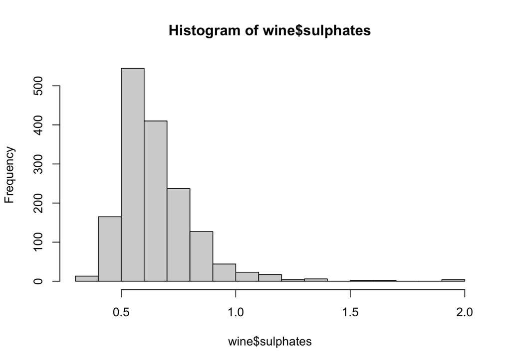

```r
hist(wine$sulphates)
```

He observes that the distribution is right-skewed. It’s often said that log-transforming right-skewed data can lead to data that is more Normally distributed; so, Professor Pablo would like you to assess whether log-transforming `sulphates` makes it Normally distributed. For this part, do the following:

- Make a histogram of the **log** of the `sulphates` variable. Choose a `bins` or `binwidth` value that you think is appropriate. Make the bars colored something other than gray or black, and (as usual) be sure your plot is properly titled and labeled.
- On top of your histogram, overlay the density curve of a Normal distribution whose mean is equal to the sample mean of `log(sulphates)` and whose standard deviation is equal to the sample standard deviation of `log(sulphates)`. Be sure that your histogram is on a scale that allows you to clearly see the density curve.
- Perform the KS test to determine whether `log(sulphates)` follows the Normal distribution you plotted in your histogram. State the conclusion from your test, and explain how you arrived to your conclusion. If you conclude that `log(sulphates)` does not follow a Normal distribution, use your histogram to discuss in 1-3 sentences what about the distribution of `log(sulphates)` makes it seem non-Normally distributed.

**Hint**: This part is mostly a review of Homework04 material. So, if you’re unsure how to do some of these tasks, I recommend revisiting Homework04 and its solutions.

*First, let’s compute the sample mean and variance, as well as the corresponding Normal density:*

```r
#sample mean and variance for log sulphates
log.mean.est = mean(log(wine$sulphates))
log.var.est = var(log(wine$sulphates))
#defining the Normal density for log sulphates
wine$sulphates.lognormDensity = dnorm(log(wine$sulphates), mean = log.mean.est, sd = sqrt(log.var.est))
```

*Now, here is the desired histogram of `log(sulphates)` on the density scale, with an overlayed density curve of a Normal distribution:*

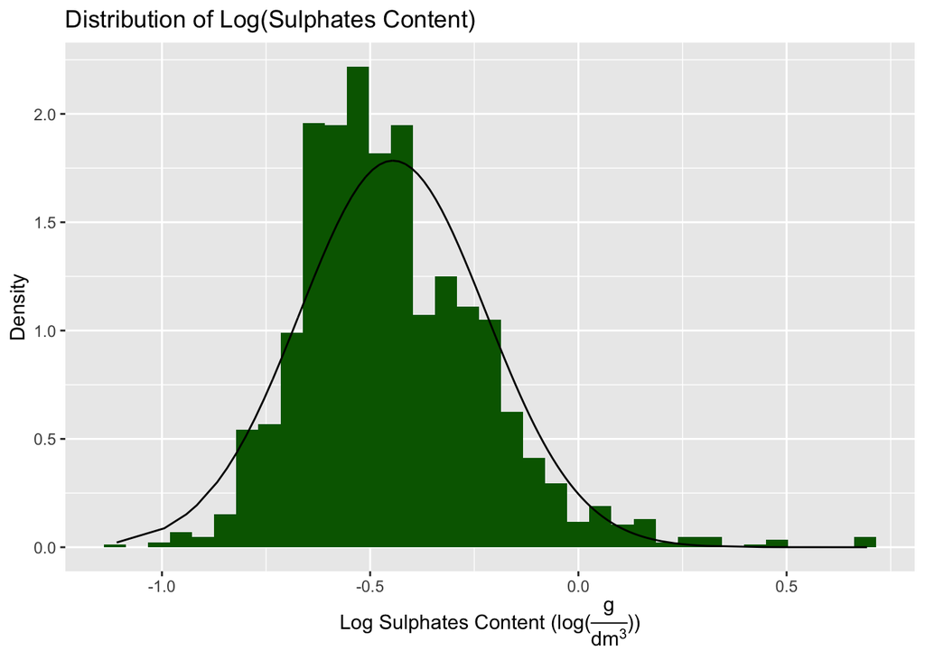

```r
library(latex2exp)
#Histogram and density curve for log sulphates
ggplot(wine, aes(x = log(sulphates))) +
  geom_histogram(aes(y=..density..), fill = "darkgreen", bins = 35) +
  geom_line(aes(log(sulphates), sulphates.lognormDensity)) +
  labs(title = "Distribution of Log(Sulphates Content)",
       x = TeX("Log Sulphates Content (log(\\frac{g}{dm^3}))"),
       y = "Density")
```

*Now we’ll perform KS test to assess if `log(sulphates)` follows a Normal distribution:*

```r
ks.test(x = log(wine$sulphates), y = "pnorm", mean = log.mean.est, sd = sqrt(log.var.est))
```

```
##
##  One-sample Kolmogorov-Smirnov test
##
## data:  log(wine$sulphates)
## D = 0.079069, p-value = 4.149e-09
## alternative hypothesis: two-sided
```

*We see that the p-value of this KS test is very small, and thus we reject the null hypothesis that `log(sulphates)` follows a Normal distribution. This makes sense - looking at our above plot, the density does not fit `log(sulphates)` well. In particular, there appears to be too much mass on the left side of the curve and not enough on the right side, such that the mode of the Normal density curve is to the right of the mode in the data.*

2. (6 points) After seeing the work you did in the previous part, Professor Pablo says, “I’ve heard that the [Shapiro-Wilk test](https://en.wikipedia.org/wiki/Shapiro%E2%80%93Wilk_test) is more powerful than the KS test to detect violations of Normality. So, given what you found in Part A, don’t you think you should use the Shapiro-Wilk test instead, since it has more power?”

Given your results in Part A, do you think Professor Pablo is bringing up a relevant point here, or do you think what he’s saying is irrelevant, given your results? By “relevant,” I mean, “Yes, the Professor Pablo is right - I should have run a test with more statistical power, and it may have given a different conclusion.” Meanwhile, by “irrelevant,” I mean, “No, running a test with more statistical power wouldn’t change my conclusion.” State whether you think Professor Pablo’s point is Relevant or Irrelevant, and then explain in 1-3 sentences.

*Professor Pablo is right that the KS test doesn’t have a lot of power, but that isn’t an issue here (i.e., this comment is Irrelevant), because, despite this low power, we still rejected the null hypothesis that the data are Normally distributed in Part A. Having low power is only an issue when you fail to reject a null hypothesis, because the rate of Type 2 errors is equal to 1 - power, meaning that low power will result in more occurences of incorrectly failing to reject the null hypothesis. However, that is Irrelevant here, because we rejected the null hypothesis. In general, rejecting the null from a low-powered test should give you a lot of confidence in that rejection, because that must mean that the null hypothesis has to be strongly violated for the low-powered test to detect that violation. In short, Professor Pablo is showing off that he read the Wikipedia page for the Shapiro-Wilk test, but he is inappropriately applying that Wikipedia knowledge here.*

3. (8pts) Now we will consider the `quality` variable. As a reminder, `quality` is an ordinal categorical variable that ranges from 0 to 10. Similar to Homework04, let’s make sure we treat `quality` as categorical:

```r
wine$quality = factor(wine$quality)
```

For this part, create a plot that you think best visualizes the conditional distribution of `log(sulphates)` given `quality`. After you’ve made your plot, answer the following questions:

- Explain in 1-3 sentences why you chose your particular plot to visualize the conditional distribution. In other words: We’ve considered several different kinds of plots for visualizing conditional distributions, so discuss why you decided to make the plot you did, rather than one of the other plots we’ve discussed in class.
- Discuss in 1-3 sentences whether you think `log(sulphates)` depends on the `quality` of wine, based on your graph.

*Ultimately you could have chosen one of several different plots for this part (e.g., conditional density curves, side-by-side boxplots, facetted histograms). Just to give a couple of examples, here is a conditional density plot and a side-by-side boxplot:*

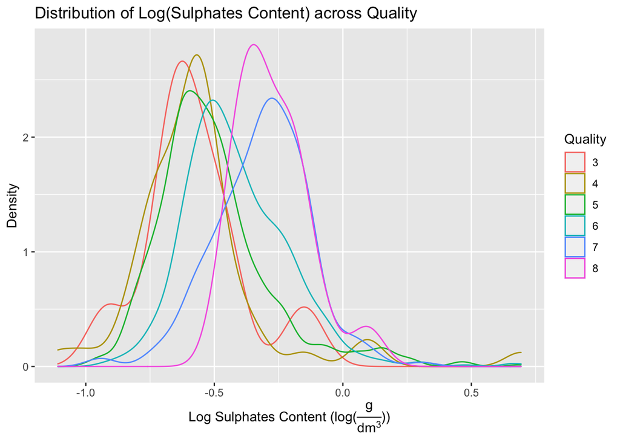

```r
#conditional density plot
ggplot(wine, aes(x = log(sulphates), color = quality)) + geom_density() +
  labs(title = "Distribution of Log(Sulphates Content) across Quality",
       x = TeX("Log Sulphates Content (log(\\frac{g}{dm^3}))"),
       y = "Density", color = "Quality")
```

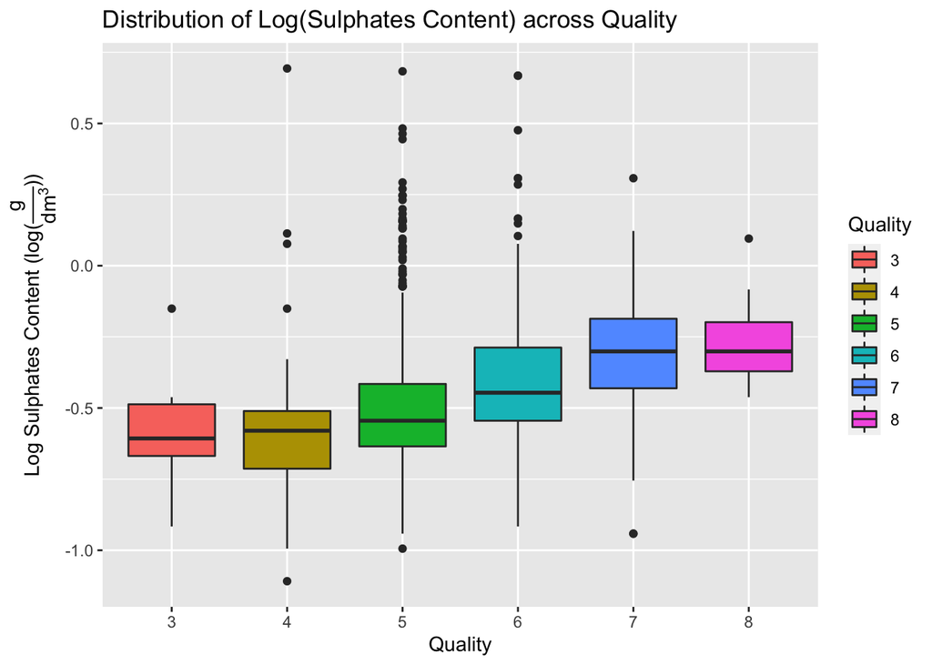

```r
#side-by-side boxplot
ggplot(wine, aes(x = quality, y = log(sulphates), fill = quality)) + geom_boxplot() +
  labs(title = "Distribution of Log(Sulphates Content) across Quality",
       y = TeX("Log Sulphates Content (log(\\frac{g}{dm^3}))"),
       x = "Quality", fill = "Quality")
```

*Looking at the conditional density plot in particular, we can see that wines with higher quality also tend to have larger values of `log(sulphates)`: `quality = 7` and `quality = 8` wines tend to have a log sulphate around -0.25, while other quality wines tend to have a log sulphate around -0.6. Furthermore, it appears that the distribution of `log(sulphates)` is fairly right-skewed for wines with quality less than 7; however, the distribution is fairly symmetric for `quality = 7` and `quality = 8` wines.*

*I decided to focus on the conditional density plot because it was easy to see the center, spread, and shape of each `log(sulphates)` distribution conditional on `quality`. The side-by-side boxplot is also a great way to see if the center and spread of `log(sulphates)` was associated with `quality`.*

4. (8 points) Professor Pablo thinks the graph you made in the previous part is pretty cool, but technically it does not communicate any formal statistical conclusions. As a follow-up to your graph in Part C, answer the following questions:
- Does the variance of `log(sulphates)` differ across different qualities? In your answer, include the code you used to run the appropriate statistical test, state your formal conclusion from this test, and explain how you arrived at your conclusion.

*As we discussed in class and lab, Bartlett’s test allows you to assess if the variance of a quantitative variable is different among different categories. Here is the code to run Bartlett’s test:*

```r
bartlett.test(log(sulphates)~quality, data = wine)
```

```
##
##  Bartlett test of homogeneity of variances
##
## data:  log(sulphates) by quality
## Bartlett's K-squared = 27.039, df = 5, p-value = 5.604e-05
```

*We see that the p-value is quite small (and certainly less than 0.05); thus, we reject the null hypothesis that the variance of `log(sulphates)` is the same across all of the `quality` groups, thereby concluding that they are different.*

- Does the mean of `log(sulphates)` differ across different qualities? Run an appropriate statistical test to answer this question. Within the function you use to answer this question, specify `var.equal = TRUE` or `var.equal = FALSE` based on your conclusion in the first part of this question. In your answer, include the code you used to run the appropriate statistical test, state your formal conclusion from this test, and explain how you arrived at your conclusion.

*As we discussed in class and lab, one-way ANOVA allows you to assess if the mean of a quantitative variable is different among different categories. Here is the code to run one-way ANOVA:*

```r
oneway.test(log(sulphates)~quality, var.equal = FALSE, data = wine)
```

```
##
##  One-way analysis of means (not assuming equal variances)
##
## data:  log(sulphates) and quality
## F = 37.523, num df = 5.000, denom df = 61.832, p-value < 2.2e-16
```

*In the one-way ANOVA, I specified `var.equal = FALSE`, because I concluded that the variances are not equal from Bartlett’s test. From the ANOVA, we get a very small p-value (certainly less than 0.05); thus, we reject the null hypothesis that the mean of `log(sulphates)` is the same across the `quality` groups, thereby concluding that they are different.*

5. (6 points) Looking at your plot in Part C and answer in Part D, Professor Pablo would like to better understand *which* quality wines are different from each other, if any. In particular, Professor Pablo asks: “Can you please tell me: Do you think the distributions of `log(sulphates)` for `quality = 3` wine and `quality = 5` wine are different?” To assess this, first define the following datasets:

```r
quality3wine = subset(wine, quality == 3)
quality5wine = subset(wine, quality == 5)
```

Then, run the appropriate KS test to answer Professor Pablo’s question. After running the test, state the p-value and formal conclusion from this test, such that you answer Professor Pablo’s question.

*Below is the code necessary to run a KS test comparing the distributions of `log(sulphates)` for `quality = 3` wine and `quality = 5` wine.*

```r
#run KS test
ks.test(log(quality3wine$sulphates), log(quality5wine$sulphates))
```

```
##
##  Two-sample Kolmogorov-Smirnov test
##
## data:  log(quality3wine$sulphates) and log(quality5wine$sulphates)
## D = 0.22717, p-value = 0.6893
## alternative hypothesis: two-sided
```

*We see that the p-value is 0.6893; thus, we fail to reject the null hypothesis that these two samples have the same distribution, thereby implicitly concluding that the distribution of `log(sulphates)` is the same for `quality = 3` wine and `quality = 5` wine. However, to be very technically correct, we can only really conclude that we do not find evidence that the distributions differ.*

6. (8 points) Now let’s visualize what the KS test in Part E is doing. The following code does this for you:

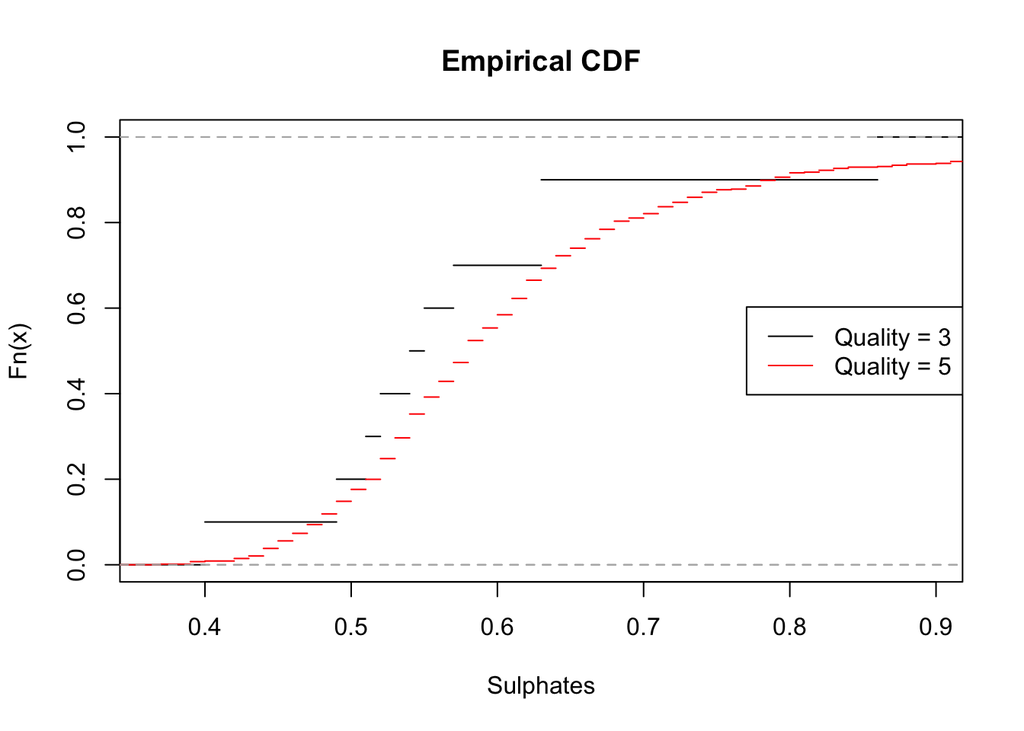

```r
plot(ecdf(quality3wine$sulphates), pch = NA, main = "Empirical CDF", xlab = "Sulphates")
lines(ecdf(quality5wine$sulphates), pch = NA, col = "red")
legend("right",
    legend = c("Quality = 3", "Quality = 5"),
        col = c("black", "red"),
        lty = 1)
```

Recreate this plot for the `sulphates` variable instead of the log-transformed `sulphates` variable—to do this, just appropriately change the above code. Then, using that plot, answer the following questions:

- After you change the plot from `log(sulphates)` to `sulphates`, you should see that the x-axis changes, but the shapes of the black and red curves stay exactly the same (meaning that the KS test gives the exact same results). Why is this? Explain in 1-3 sentences.

*The shape of these curves are exactly the same as the curves for log(sulphates). The reason is that, as we discussed in class, each “step” in the empirical CDF increases whenever there is a new unique value of `log(sulphates)` as we go from left to right (i.e., as we go from very negative values to more positive values). Since log() is a monotonic function, these increases will occur in the same relative place for `sulphates` and `log(sulphates)`, because the ordering of observations from most negative to most positive will not change.*

*To put it another way: Let $\hat{F}(x)$ be the empirical CDF for sulphates, and let $\hat{F}_{\ell}(x)$ be the empirical CDF for `log(sulphates)`. $\hat{F}(x)$ is defined as the proportion of sulphates that are less than x; this will be equal to the proportion of `log(sulphates)` that are less than `log(x)` (again, this is because log is a monotonic function). This is why $\hat{F}(x)$ and $\hat{F}_{\ell}(x)$ will have the same shape, but different x-axes.*

*Finally, you can also see this equivalence by running the KS test for `sulphates` and `log(sulphates)`; they yield the exact same results:*

```r
ks.test(quality3wine$sulphates, quality5wine$sulphates)
```

```
##
##  Two-sample Kolmogorov-Smirnov test
##
## data:  quality3wine$sulphates and quality5wine$sulphates
## D = 0.22717, p-value = 0.6893
## alternative hypothesis: two-sided
```

```r
ks.test(log(quality3wine$sulphates), log(quality5wine$sulphates))
```

```
##
##  Two-sample Kolmogorov-Smirnov test
##
## data:  log(quality3wine$sulphates) and log(quality5wine$sulphates)
## D = 0.22717, p-value = 0.6893
## alternative hypothesis: two-sided
```

- In the plot, there are a lot more red lines than black lines. Why is this? Provide some evidence from the data to support your explanation.

*There are a lot more red lines than black lines in the plot because there are many more `quality = 5` wines than `quality = 3` wines. We can see this by looking at the number of rows for each of these subsets of the data:*

```r
nrow(quality3wine); nrow(quality5wine)
```

```
## [1] 10
```

```
## [1] 681
```

- In the plot, the vertical gap between each individual red line is bigger on the left-hand side of the plot than on the right-hand side of the plot. Why is this? Provide some evidence from the data to support your explanation.

*As mentioned earlier, in the empirical CDF, there will be a “step” for every unique value of `sulphates`. If there is only a single observation with that unique value, the corresponding step will increase by 1/n; however, if there are $j$ observations with that unique value, the corresponding step will increase by $j/n$. Thus, the fact that the “steps” have bigger gaps on the left-hand side of the plot suggests that there are more observations with the same `sulphates` value for low-valued `sulphates`. Indeed, by looking at a table of unique values of `sulphates` within `quality = 5` wines, we can see that there are many observations with the same `sulphates` value when `sulphates` is small, but not when it is large:*

```r
table(quality5wine$sulphates)
```

```
##
## 0.37 0.39  0.4 0.42 0.43 0.44 0.45 0.46 0.47 0.48 0.49  0.5 0.51 0.52 0.53 0.54
##    1    4    1    4    4   12   12   12   14   17   20   19   16   33   33   38
## 0.55 0.56 0.57 0.58 0.59  0.6 0.61 0.62 0.63 0.64 0.65 0.66 0.67 0.68 0.69  0.7
##   27   25   30   35   20   21   26   29   19   20   12   15   15   13    5    7
## 0.71 0.72 0.73 0.74 0.75 0.76 0.77 0.78 0.79  0.8 0.81 0.82 0.83 0.84 0.86 0.87
##   11    7    8    8    4    1    5    9    5    7    1    3    3    2    1    2
## 0.88  0.9 0.91 0.93 0.94 0.95 0.97 0.98 0.99 1.02 1.03 1.05 1.06 1.07 1.09  1.1
##    2    1    3    4    1    1    2    1    1    1    1    2    1    2    1    1
## 1.14 1.15 1.17 1.18  1.2 1.22 1.26 1.28 1.31 1.34 1.56 1.59 1.62 1.98
##    2    1    5    1    1    1    1    2    1    1    1    1    1    1
```

*Thus, when we look at the above table from lowest values to highest values, we know that the “step” of the red lines increases by 1/n at 0.37, but then 4/n for 0.39, and so on.*

7. (4pts) Given your finding from the KS test in Part E and your discussion in Part F, do you think Professor Pablo now has a point to critique the KS test because of its low statistical power (at least in terms of its use as a two-sample KS test to compare `quality = 3` and `quality = 5` wines)? State Yes or No, and then explain in 1-3 sentences.

**Hint**: This question is related to the second bullet point in Part F, so I would think about why.

*Yes, they now have a point to critique the KS test because of its low statistical pwer. As mentioned in the previous part, we can see that small sample size may be a concern here (in the sense that the sample size for `quality = 3` wines is quite small). In particular, we noted in class that, for low-powered tests, you often need a large sample in order to detect differences in distributions. The fact that the KS test has low power may indeed be why we failed to reject the null hypothesis in Part E. As we noted earlier, low power is only a concern when you fail to reject the null hypothesis (as we have done here), and not when we reject the null hypothesis.*

8. (4pts) Now that you’ve shown Professor Pablo how to do a two-sample KS test, he decides to do another one on his own. He states the following:

“I did a two-sample KS test comparing the distribution of `log(sulphates)` for `quality = 3` and `quality = 8` wines. I got a p-value of 0.0002. This makes me confused - I thought the KS test would have especially low power here, because the sample sizes for `quality = 3` and `quality = 8` wines are so small. So, why is the p-value from this KS test so small?”

In 1-3 sentences, answer Professor Pablo’s question using the graph you made in Part C. You don’t need to include another graph here, but be sure to mention how you used your Part C graph to answer the question being asked here.

**Hint**: Professor Pablo isn’t trying to trick you; it’s true that the p-value from the KS test really is 0.0002, and that the sample sizes for `quality = 3` and `quality = 8` wines are very small.

*It is true that the KS test will tend to have low power in this scenario, because the sample sizes for `quality = 3` and `quality = 8` wines are so small:*

```r
table(wine$quality)
```

```
##
##   3   4   5   6   7   8
##  10  53 681 638 199  18
```

*However, looking back at our conditional density plot in Part C, we can see that the `log(sulphates)` distributions for `quality = 3` and `quality = 8` wines are quite different: In particular, the center of the former distribution is to the left of the latter, such that the distributions only somewhat overlap. Because of this substantial difference in the distributions, the KS test is able to detect this difference, despite the low statistical power.*

*[More generally, the power of statistical tests is not only affected by sample size, but also the size of the effect. For example, if we were to use a t-test assessing if two population means are different, we would have a lot of power if those means are quite far apart, but only a little power if those means were very close together. This is intuitive: It’s easier to detect big differences than small differences, in the sense that big differences “stand out more” and are thus easier to see/detect. Because there are big differences in the `log(sulphates)` distributions for `quality = 3` and `quality = 8` wines, the KS test still had a fair amount of power to detect this difference, despite the small sample size.]*

# Problem 2: Ridgeline Plots (25 points)

In this problem we will talk about a relatively new kind of plot called a “ridgeline plot,” which was developed by [Claus O. Wilke](https://clauswilke.com/) a few years ago. In short, ridgeline plots are overlapping density plots that look like a mountain range; they are sometimes called “joy plots” because of their similarity to the [famous cover](https://www.typeroom.eu/assets/original/2020/05/18/JoyDivision-UnknownPleasures-B1.jpg) of the Joy Division album Unknown Pleasures. Although we haven’t discussed ridgeline plots in class or lab, they use the exact same smoothed-density concepts that we’ve discussed—this is meant to demonstrate that the things you learn in 36-315 will (hopefully) prepare you for all sorts of neat plots you’ll see in the data science world.

To make ridgeline plots, you’ll need to install the `ggridges` `R` package; do that now by running `install.packages("ggridges")` in your Console. I’ve found that you need to restart RStudio after installing the package; so, do that, and then load the `ggridges` library:

```r
library(ggridges)
```

If you run into any issues installing the `ggridges` R package, reach out to Professor Branson.

This problem walks you through the basics of this package, which are further demonstrated in [this tutorial](https://cran.r-project.org/web/packages/ggridges/vignettes/introduction.html). You *do not* need to read this tutorial to do this problem, but it is there for reference in case you are interested.

1. (5pts) After you’ve installed the `ggridges` package, you should be able to run the following line of code:

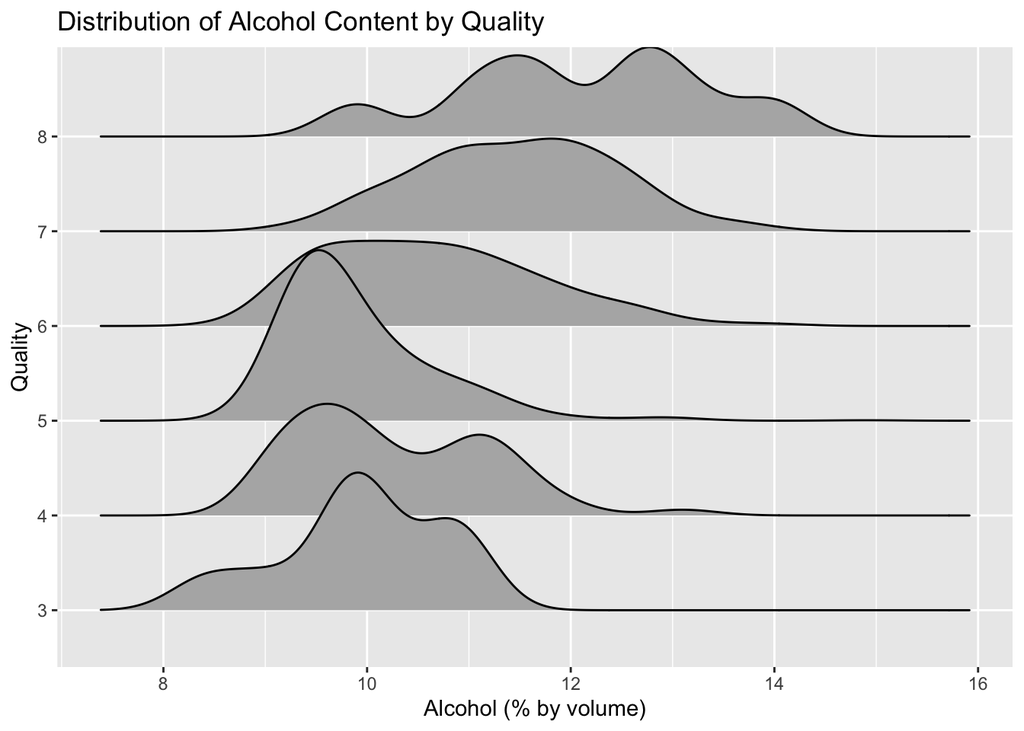

```r
ggplot(data = wine, aes(x = alcohol, y = quality)) + geom_density_ridges() + labs(title = "Distribution of Alcohol Content by Quality", x = "Alcohol (% by volume)", y = "Quality")
```

For this part, just uncomment the above line of code, and add an appropriate title/labels. (Notice that this code is super similar to the `ggplot` code we’ve seen previously, which is nice!) Then, answer the following questions:

- What distribution is this plot showing?

*This is showing the conditional distribution of `alcohol` given `quality`.*

- Write your interpretation of this plot in 1-3 sentences. Be sure to compare and contrast the center, spread, and shape of the distributions.

*We see that center of `alcohol` somewhat increases for higher `quality` wines. Furthermore, wines with `quality` at least 6 tend to have a larger spread in `alcohol` content, compared to lower-quality wines. Finally, the modality of `alcohol` seems to vary across `quality`; we see that quality 5, 6, and 7 wines tend to have a unimodal distribution in `alcohol`, whereas the other distributions (for quality 3, 4, and 8) have a multimodal distribution.*

2. (5pts) As you can see in Part A, the ridgeline plot plots overlapping smoothed densities. As we discussed in class, when plotting smoothed densities, you must estimate a *bandwidth*. By default, `geom_density_ridges()` estimates a *single* bandwidth that is used for all the densities in the plot. Alternatively, you can force `geom_density_ridges()` to estimate a *different* bandwidth for each density by doing the following:
- Copy-and-paste your code from Part A
- Add `height = stat(density)` within `aes()`.
- Add `stat = "density"` within `geom_density_ridges()`.

Make another ridgeline plot by following the above three steps. Then, compare and contrast the plot you made here with the plot you made in Part A. In particular: Which smoothed densities look similar, and which smoothed densities look different?

*Following the steps above, we get the following plot:*

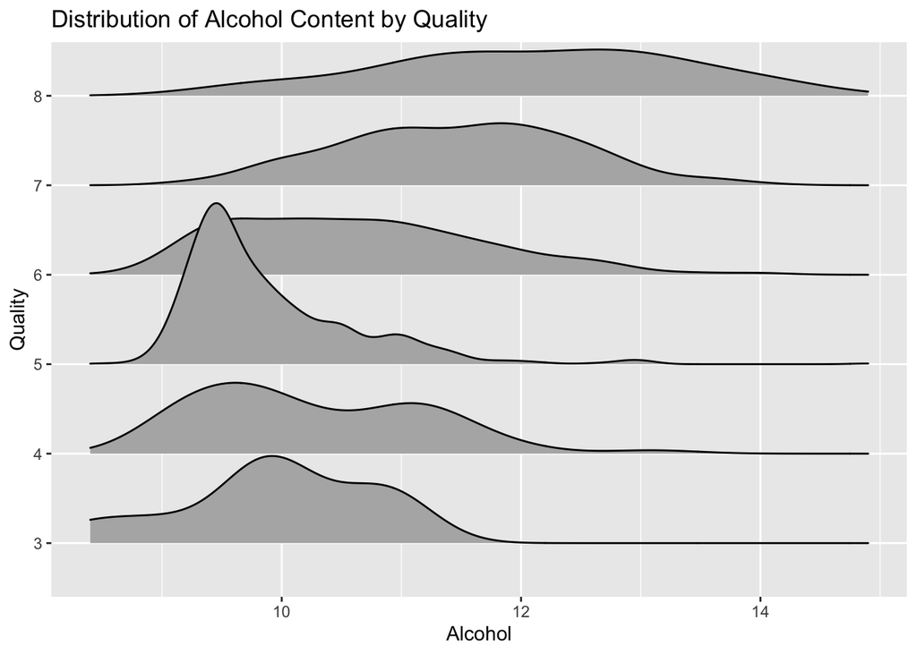

```r
ggplot(data = wine, aes(x = alcohol, y = quality, height = stat(density))) + geom_density_ridges(stat = "density") + labs(title = "Distribution of Alcohol Content by Quality", x = "Alcohol", y = "Quality")
```

*Most of the densities look similar, but the `quality = 8` density here definitely looks different here, compared to the `quality = 8` density in Part A. In Part A, this density was clearly multimodal, whereas it seems unimodal here.*

*[If you want to really squint at these two plots, it seems like the modality is somewhat dampened for `quality = 3` and `quality = 4` wines here, whereas the modality is somewhat exaggerated in the right-tail for `quality = 5` wines, compared to that seen in Part A. However, the biggest difference in the densities is definitely for the `quality = 8` wines.]*

3. (5pts) Let’s focus on the `quality = 8` density in Part A and Part B. When you ran your code in Part A, `R` should have printed out the following message: “Picking joint bandwidth of 0.338.” This means that a bandwidth of 0.338 was used for all the densities in Part A. Meanwhile, the plot in Part B estimates a different bandwidth for each density. Given this: Do you think the bandwidth estimated for the `quality = 8` density in Part B is greater than or less than 0.338? Explain your answer in 1-2 sentences.

*It should be greater than 0.338, because the density in Part B is smoother than the density in Part A, and larger bandwidths lead to smoother densities.*

*To confirm this, we can check the actual bandwidth used in the plot by using the `density()` function:*

```r
#create a subset of quality = 8 wines
quality8wine = subset(wine, quality == 8)
density(quality8wine$alcohol)$bw
```

```
## [1] 0.5840028
```

4. (4pts) We will discuss just two more functionalities in `ggridges`. The previous plots visualize smoothed densities; you can also visualize histograms. To do this, follow these steps:
- Copy-and-paste your code from Part B.
- Within `geom_density_ridges()`, change `stat = "density"` to `stat = "binline"`.
- Within `geom_density_ridges()`, set `scale = 0.9`.

Note that you should still have `height = stat(density)` within `aes()`. The `scale = 0.9` line ensures that individual distributions won’t overlap, which is helpful for histograms.

First, create the histogram ridgeline plot by following the above three steps. You should get a message that should look familiar: “`stat_binline()` using `bins = 30`. Pick better value with `binwidth`.” Within `geom_density_ridges()`, specify a `bins` value that you think is more appropriate.

For this part, all you have to do is turn in a histogram ridgeline plot with a `bins` value specified.

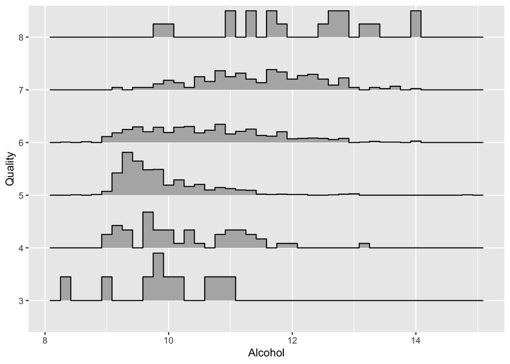

```r
ggplot(data = wine, aes(x = alcohol, y = quality, height = stat(density))) + geom_density_ridges(stat = "binline", scale = 0.9, bins = 40) + labs("Distribution of Alcohol Content by Quality", x = "Alcohol", y = "Quality")
```

5. (6pts) Let’s take a closer look at the `alcohol` variable, which we’ve been visualizing in this question:

```r
summary(wine$alcohol)
```

```
##    Min. 1st Qu.  Median    Mean 3rd Qu.    Max.
##    8.40    9.50   10.20   10.42   11.10   14.90
```

You can see that the median is around 10, and `alcohol` ranges from (rougly) 8 to 15. After seeing this, I decided to make the following plot (all you have to do is uncomment):

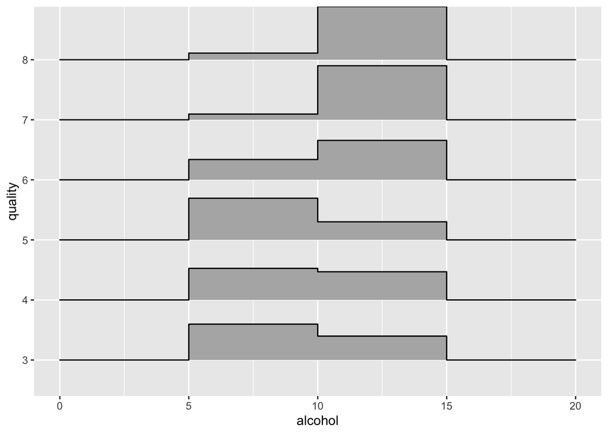

```r
ggplot(data = wine, aes(x = alcohol, y = quality, height = stat(density))) + geom_density_ridges(stat = "binline", breaks = c(5,10,15), scale = 0.9)
```

After uncommenting the code (and thus creating the plot), answer the following questions:

- Which `quality` appears to have the highest proportion of “low alcohol wines” (where “low alcohol” means `alcohol` less than or equal to 10)?

*`quality = 5` appears to have the highest proportion of “low alcohol wines.” (This is because the relative height of the left bar is highest for `quality = 5` wines.)*

- Which `quality` appears to have the highest proportion of “high alcohol wines” (where “high alcohol” means `alcohol` greater than or equal to 10)?

*`quality = 7` appears to have the highest proportion of “high alcohol wines.” (This is because the relative height of the right bar is highest for `quality = 7` wines.) We can note that `quality = 8` also has a very high proportion of “high alcohol wines”; you have to squint at the plot pretty closely to see that `quality = 7` has a higher proportion, so it’s okay if you said `quality = 8` here.*

- Which `quality` appears to have a roughly equal proportion of “low alcohol wines” and “high alcohol wines”?

*`quality = 4` appears to have a roughly equal proportion of “low alcohol wines” and “high alcohol wines” (This is because the relative height of the left bar and right bars is nearly equal for `quality = 4` wines.)*

# Problem 3: Looking at a Quantitative Variable and Two Categorical Variables (19 points)

For this part, we will continue to look at `log(sulphates)` and `quality` (as in Problem 1), but also consider `alcohol` (as in Problem 2).

1. (4pts) In previous assignments, we’ve seen how facets can be used to easily add a categorical variable into a data visualization, and smoothed densities are no different. For this part, use smooothed densities to visualize the conditional distribution of `log(sulphates)` given `quality` for (1) wines with a “high level” of alcohol content (`alcohol > 10`), and (2) wines with a “low level” of alcohol content (`alcohol <= 10`). In other words, your plot should have two facets (one for “high alcohol” wines and one for “low alcohol” wines), and each facet should have multiple smoothed density curves of `log(sulphates)`, one for each `quality` of wine.

**Hint**: To do this, first create a plot of smoothed density curves for `log(sulphates)` given `quality`, ignoring `alcohol` entirely. Then, create a categorical version of the `alcohol` variable, set equal to “High” if `alcohol > 10` and “Low” otherwise. Finally, you should be able to use this new categorical variable to facet your smoothed density curve plot.

*As mentioned in the hint, it’s helpful to first create a categorical variable representing “high” and “low” alcohol wines:*

```r
wine$alcoholCat = ifelse(wine$alcohol <= 10, "low", "high")
```

*Then, we can plot a conditional smoothed density of `log(sulphates)` given quality, facetted by this categorical variable:*

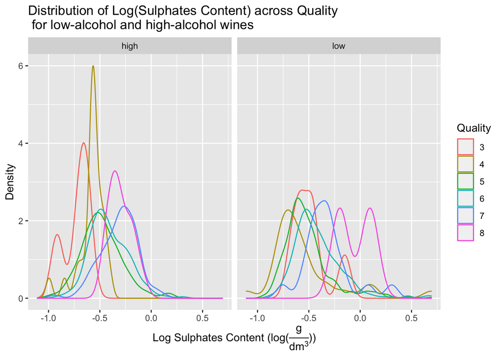

```r
ggplot(wine, aes(x = log(sulphates), color = quality)) + geom_density() +
  facet_grid(~alcoholCat) +
  labs(title = "Distribution of Log(Sulphates Content) across Quality \n for low-alcohol and high-alcohol wines",
       x = TeX("Log Sulphates Content (log(\\frac{g}{dm^3}))"),
       y = "Density", color = "Quality")
```

2. (5pts) If you made your plot in Part A correctly, you should find the following:
- The distribution of `log(sulphates)` given `quality = 8` for “low alcohol” wines is distinctly bimodal.
- The distribution of `log(sulphates)` given `quality = 3` for “high alcohol” wines is distinctly bimodal.

For the first distribution (where `quality = 8` and alcohol is “low”), how many wines belong to the left-hand mode, and how many wines belong to the right-hand mode? Similarly, for the second distribution (where `quality = 3` and alcohol is “high”), how many wines belong to the left-hand mode, and how many wines belong to the right-hand mode? In addition to your answer to these questions, please include any code you used to arrive at your answer (and explain how you arrived at your answer).

*First, let’s look at the number of observations that have `quality = 8` and low alcohol content:*

```r
nrow( subset(wine, quality == 8 & alcoholCat == "low") )
```

```
## [1] 2
```

*There are only two observations, which means that there must be only one observation that belongs to each of the two modes for the `quality = 8` “low alcohol” wine distribution. This also explains why the two modes are exactly the same height and shape.*

*Now let’s look at the number of observations that have `quality = 3` and high alcohol content:*

```r
nrow( subset(wine, quality == 3 & alcoholCat == "high") )
```

```
## [1] 4
```

*There are four; because the right-hand mode of this distribution is about three-times the height of the other mode, we can deduce that three observations are in the right-hand mode and one observation is in the left-hand mode. To validate this, let’s look at the values of `log(sulphates)` for these four wines:*

```r
log(subset(wine, quality == 3 & alcoholCat == "high")$sulphates)
```

```
## [1] -0.6161861 -0.7133499 -0.9162907 -0.6539265
```

*Indeed, we can see that only one observation has a very low `log(sulphates)` value, and thus only one observation belongs to that left-hand mode for high-alcohol wines with `quality = 3`. Meanwhile, the other three observations (which have similar `log(sulphates)` belong to the right-hand mode of this distribution.*

3. (6pts) Looking at your plot, [Professor A. Fletcher](https://en.wikipedia.org/wiki/The_Copyrights) states, “When we look at high-alcohol wines with `quality = 4`, the density seems to be much higher than the density for low-alcohol wines with `quality = 4`. Thus, this must mean that there are more high-alcohol wines with `quality = 4` than low-alcohol wines with `quality = 4`.”

For this part, state whether you Agree or Disagree with this statement, and explain your answer in 1-3 sentences. In your answer, be sure to explain why there is a higher density for high-alcohol wines with `quality = 4` than for low-alcohol wines with `quality = 4` (it could be because of sample size - which is what Professor Fletcher is saying - or it could be because of something else).

*First, we can quickly check whether or not there are actually more high-alcohol wines with `quality = 4` than low-alcohol wines with `quality = 4`:*

```r
#number of wines with high alcohol and quality = 4
nrow( subset(wine, quality == 4 & alcoholCat == "high") )
```

```
## [1] 25
```

```r
#number of wines with low alcohol and quality = 4
nrow( subset(wine, quality == 4 & alcoholCat == "low") )
```

```
## [1] 28
```

*There are actually more low-alcohol wines with `quality = 4` than high-alcohol wines with `quality = 4`; so, we Disagree with the statement. When looking at conditional smoothed densities, it’s important to remember that every density integrates to 1 (i.e., the total area under each smoothed density curve is 1). Thus, the density for a particular subgroup is relative only to that subgroup, not the entire dataset. Thus, the reason that there is a higher density of high-alcohol wines with `quality = 4` compared to low-alcohol wines with `quality = 4` must be because there is a relatively higher concentration of wines with similar `log(sulphates)` values for high-alcohol wines. We can validate this by looking at summary statistics of `log(sulphates)` for these two types of wines:*

```r
#summary stats for log(sulphates) for high alcohol and quality = 4
summary( log(subset(wine, quality == 4 & alcoholCat == "high")$sulphates) )
```

```
##    Min. 1st Qu.  Median    Mean 3rd Qu.    Max.
## -0.9943 -0.5978 -0.5621 -0.5835 -0.5108 -0.4005
```

```r
#summary stats for log(sulphates) for low alcohol and quality = 4
summary( log(subset(wine, quality == 4 & alcoholCat == "low")$sulphates) )
```

```
##    Min. 1st Qu.  Median    Mean 3rd Qu.    Max.
## -1.1087 -0.7340 -0.6444 -0.5438 -0.5067  0.6931
```

*Looking at the summary statistics for high-alcohol wines, we can see that `log(sulphates)` has a smaller range and smaller spread (as measured by IQR); in other words, there is a higher relative concentration of wines with similar `log(sulphates)` values for high-alcohol wines, thereby leading to a higher density (even though there isn’t a big difference in sample size, compared to low-alcohol wines).*

4. (4pts) As you’ve (hopefully) seen in this question, it can be helpful to include information about sample size in smoothed density plots. To do this, copy-and-paste your code from Part A, and add a “rug” to your plot. For this part, you only need to include the desired smoothed density plot from Part A, but with a rug added. (**Hint**: If you can’t remember how to add a rug to a plot, revisit Lab04.)

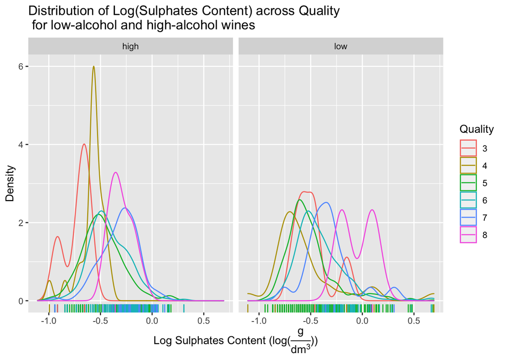

```r
ggplot(wine, aes(x = log(sulphates), color = quality)) + geom_density() + geom_rug() +
  facet_grid(~alcoholCat) +
  labs(title = "Distribution of Log(Sulphates Content) across Quality \n for low-alcohol and high-alcohol wines",
       x = TeX("Log Sulphates Content (log(\\frac{g}{dm^3}))"),
       y = "Density", color = "Quality")
```